# Modelado Predictivo de Agresividad Tumoral — TCGA-PRAD

TFM — Integración de Transcriptómica Tumoral y Actividad Metabólica Inferida (Incluyendo variable ganglionar)

Jose Pablo Delgado Navarro

01 de mayo de 2026

# 1 Introducción

Este script evalúa el impacto de la variable ganglionar (`ajcc_pathologic_n`) sobre el rendimiento predictivo de los modelos desarrollados en el Script 04. La pregunta es directa: **¿vale la pena perder ~15% de las muestras a cambio de incluir el estado ganglionar como predictor clínico?**

Se comparan dos configuraciones bajo el mismo esquema de validación (repeated CV 5×5):

[output not shown]

**Nota:** el modelo GSVA y el modelo integrado también se ven afectados porque el dataset de base cambia. Los scores GSVA son los mismos (se calcularon sobre las 497 muestras en el Script 03), pero el subconjunto analizable varía.

# 2 1. Carga de datos

**Tabla 1.** Disponibilidad de datos antes de la construcción de los datasets.

| Parametro | Valor |
| --- | --- |
| Muestras totales disponibles | 496 |
| Endpoint — Baja agresividad | 45 |
| Endpoint — Agresividad intermedia | 246 |
| Endpoint — Alta agresividad | 205 |
| Pacientes con estado ganglionar registrado | 423 |
| Pacientes sin estado ganglionar (NX o NA) | 73 |

# 3 2. Construcción de los datasets

```r
# Transponer la matriz GSVA
gsva_df <- as.data.frame(t(gsva_matrix))
gsva_df$bcr_patient_barcode <- substr(rownames(gsva_df), 1, 12)

# --- DATASET A: con variable ganglionar (replica exacta del Script 04) ---
clinical_A <- clinical_final %>%
  dplyr::select(bcr_patient_barcode, agresividad,
                t_stage_simple, ajcc_pathologic_n,
                residual_disease, age) %>%
  mutate(
    t_stage_num = case_when(
      t_stage_simple == "T2" ~ 2,
      t_stage_simple == "T3" ~ 3,
      t_stage_simple == "T4" ~ 4,
      TRUE                   ~ NA_real_
    ),
    n_stage_num = case_when(
      ajcc_pathologic_n == "N0" ~ 0,
      ajcc_pathologic_n == "N1" ~ 1,
      TRUE                      ~ NA_real_
    ),
    residuo_num = case_when(
      residual_disease == "R0" ~ 0,
      residual_disease %in% c("R1", "R2") ~ 1,
      TRUE                     ~ NA_real_
    )
  ) %>%
  filter(!is.na(t_stage_num), !is.na(n_stage_num), !is.na(residuo_num))

dataset_A <- clinical_A %>%
  left_join(gsva_df, by = "bcr_patient_barcode")

# --- DATASET B: sin variable ganglionar ---
clinical_B <- clinical_final %>%
  dplyr::select(bcr_patient_barcode, agresividad,
                t_stage_simple, residual_disease, age) %>%
  mutate(
    t_stage_num = case_when(
      t_stage_simple == "T2" ~ 2,
      t_stage_simple == "T3" ~ 3,
      t_stage_simple == "T4" ~ 4,
      TRUE                   ~ NA_real_
    ),
    residuo_num = case_when(
      residual_disease == "R0" ~ 0,
      residual_disease %in% c("R1", "R2") ~ 1,
      TRUE                     ~ NA_real_
    )
  ) %>%
  filter(!is.na(t_stage_num), !is.na(residuo_num))

dataset_B <- clinical_B %>%
  left_join(gsva_df, by = "bcr_patient_barcode")
```

**Tabla 2.** Comparación de los dos datasets.

| Configuración | N total | Baja (n) | Intermedia (n) | Alta (n) | Variables clínicas |
| --- | --- | --- | --- | --- | --- |
| Dataset A (con ganglios) | 397 | 21 | 198 | 178 | 4 |
| Dataset B (sin ganglios) | 461 | 41 | 230 | 190 | 3 |

# 4 3. Esquema de validación cruzada

Se usa el mismo esquema que el Script 04; repeated CV estratificada 5×5 (25 iteraciones). Los folds se crean de forma independiente para cada dataset para respetar su distinta distribución de clases.

```r
# Folds para Dataset A
set.seed(1229)
folds_A <- createMultiFolds(
  y     = dataset_A$agresividad,
  k     = 5,
  times = 5
)
y_all_A <- factor(dataset_A$agresividad,
                  levels = c("Baja", "Intermedia", "Alta"))

# Folds para Dataset B
set.seed(1229)
folds_B <- createMultiFolds(
  y     = dataset_B$agresividad,
  k     = 5,
  times = 5
)
y_all_B <- factor(dataset_B$agresividad,
                  levels = c("Baja", "Intermedia", "Alta"))
```

```
## === Dataset A (con ganglios) ===
```

```
## Iteraciones: 25
```

```
## Train por fold (aprox): 318
```

```
## Test por fold (aprox):  79
```

```
## Distribución de clases (%):
```

```
## y_all_A
##       Baja Intermedia       Alta
##        5.3       49.9       44.8
```

```
##
## === Dataset B (sin ganglios) ===
```

```
## Iteraciones: 25
```

```
## Train por fold (aprox): 369
```

```
## Test por fold (aprox):  92
```

```
## Distribución de clases (%):
```

```
## y_all_B
##       Baja Intermedia       Alta
##        8.9       49.9       41.2
```

# 5 4. Función auxiliar de modelado

Para evitar duplicar código, se define una función que corre el pipeline completo (Elastic Net con tuning de alpha + Random Forest) sobre cualquier dataset y conjunto de folds.

```r
set.seed(1229)
run_models <- function(dataset, folds, y_all, vars_clinicas) {

  alpha_grid <- c(0, 0.25, 0.5, 0.75, 1.0)
  n_iter     <- length(folds)

  # Matrices de predictores
  X_clin <- dataset %>%
    dplyr::select(all_of(vars_clinicas)) %>%
    as.matrix()

  X_gsva <- dataset %>%
    dplyr::select(starts_with("HALLMARK_")) %>%
    as.matrix()

  X_int <- cbind(X_clin, X_gsva)

  # Inicializar vectores y listas
  auc_clin  <- numeric(n_iter)
  auc_gsva  <- numeric(n_iter)
  auc_en    <- numeric(n_iter)
  auc_rf    <- numeric(n_iter)

  alpha_clin_folds <- numeric(n_iter)
  alpha_gsva_folds <- numeric(n_iter)
  alpha_int_folds  <- numeric(n_iter)

  probs_clin_list <- vector("list", n_iter)
  probs_gsva_list <- vector("list", n_iter)
  probs_en_list   <- vector("list", n_iter)
  probs_rf_list   <- vector("list", n_iter)
  y_test_list     <- vector("list", n_iter)

  tune_alpha <- function(X_train, y_train, alpha_grid) {
    alpha_grid[which.max(sapply(alpha_grid, function(a) {
      cv_a <- cv.glmnet(
        x            = X_train,
        y            = y_train,
        family       = "multinomial",
        alpha        = a,
        nfolds       = 5,
        type.measure = "class"
      )
      -min(cv_a$cvm)
    }))]
  }

  for (i in seq_along(folds)) {
    idx_train <- folds[[i]]
    idx_test  <- setdiff(seq_len(nrow(X_int)), idx_train)

    y_test_list[[i]] <- y_all[idx_test]

    # --- Modelo clínico ---
    set.seed(1229)
    alpha_clin_folds[i] <- tune_alpha(X_clin[idx_train, ], y_all[idx_train], alpha_grid)
    set.seed(1229)
    fit_clin <- cv.glmnet(
      x = X_clin[idx_train, ], y = y_all[idx_train],
      family = "multinomial", alpha = alpha_clin_folds[i],
      nfolds = 5, type.measure = "class"
    )
    p_clin <- predict(fit_clin, newx = X_clin[idx_test, ],
                      s = "lambda.min", type = "response")[, , 1]
    probs_clin_list[[i]] <- p_clin
    auc_clin[i] <- auc_ova(y_all[idx_test], p_clin)

    # --- Modelo GSVA ---
    set.seed(1229)
    alpha_gsva_folds[i] <- tune_alpha(X_gsva[idx_train, ], y_all[idx_train], alpha_grid)
    set.seed(1229)
    fit_gsva <- cv.glmnet(
      x = X_gsva[idx_train, ], y = y_all[idx_train],
      family = "multinomial", alpha = alpha_gsva_folds[i],
      nfolds = 5, type.measure = "class"
    )
    p_gsva <- predict(fit_gsva, newx = X_gsva[idx_test, ],
                      s = "lambda.min", type = "response")[, , 1]
    probs_gsva_list[[i]] <- p_gsva
    auc_gsva[i] <- auc_ova(y_all[idx_test], p_gsva)

    # --- Modelo integrado Elastic Net ---
    set.seed(1229)
    alpha_int_folds[i] <- tune_alpha(X_int[idx_train, ], y_all[idx_train], alpha_grid)
    set.seed(1229)
    fit_en <- cv.glmnet(
      x = X_int[idx_train, ], y = y_all[idx_train],
      family = "multinomial", alpha = alpha_int_folds[i],
      nfolds = 5, type.measure = "class"
    )
    p_en <- predict(fit_en, newx = X_int[idx_test, ],
                    s = "lambda.min", type = "response")[, , 1]
    probs_en_list[[i]] <- p_en
    auc_en[i] <- auc_ova(y_all[idx_test], p_en)

    # --- Modelo integrado Random Forest ---
    set.seed(1229)
    fit_rf <- randomForest(
      x = X_int[idx_train, ], y = y_all[idx_train], ntree = 500
    )
    p_rf <- predict(fit_rf, newdata = X_int[idx_test, ], type = "prob")
    probs_rf_list[[i]] <- p_rf
    auc_rf[i] <- auc_ova(y_all[idx_test], p_rf)
  }

  list(
    auc_clin  = auc_clin,
    auc_gsva  = auc_gsva,
    auc_en    = auc_en,
    auc_rf    = auc_rf,
    alpha_clin = alpha_clin_folds,
    alpha_gsva = alpha_gsva_folds,
    alpha_int  = alpha_int_folds,
    probs_clin = probs_clin_list,
    probs_gsva = probs_gsva_list,
    probs_en   = probs_en_list,
    probs_rf   = probs_rf_list,
    y_test     = y_test_list,
    X_clin     = X_clin,
    X_gsva     = X_gsva,
    X_int      = X_int,
    y_all      = y_all
  )
}
```

# 6 5. Ejecución — Dataset A

```r
set.seed(1229)
res_A <- run_models(
  dataset      = dataset_A,
  folds        = folds_A,
  y_all        = y_all_A,
  vars_clinicas = c("t_stage_num", "n_stage_num", "residuo_num", "age")
)
```

```
## === Dataset A (con ganglios, n = 397 ) ===
```

```
## Modelo clínico    — AUC: 0.746 ± 0.048
```

```
## Modelo GSVA       — AUC: 0.717 ± 0.045
```

```
## Integrado (EN)    — AUC: 0.759 ± 0.052
```

```
## Integrado (RF)    — AUC: 0.751 ± 0.049
```

# 7 6. Ejecución — Dataset B

```r
res_B <- run_models(
  dataset       = dataset_B,
  folds         = folds_B,
  y_all         = y_all_B,
  vars_clinicas = c("t_stage_num", "residuo_num", "age")
)
```

```
## === Dataset B (sin ganglios, n = 461 ) ===
```

```
## Modelo clínico    — AUC: 0.729 ± 0.037
```

```
## Modelo GSVA       — AUC: 0.741 ± 0.036
```

```
## Integrado (EN)    — AUC: 0.762 ± 0.042
```

```
## Integrado (RF)    — AUC: 0.757 ± 0.04
```

# 8 7. Comparación directa A vs B

## 8.1 7.1 Tabla comparativa

**Tabla 3.** AUC medio ± DE por modelo y configuración de dataset. Repeated CV 5×5 (25 iteraciones).

[output not shown]

## 8.2 7.2 Diferencias en AUC (B − A)

**Tabla 4.** Diferencia en AUC medio entre Dataset B (sin ganglios) y Dataset A (con ganglios). Valores positivos indican que el Dataset B obtiene mejor AUC.

| Modelo | AUC — Dataset A | AUC — Dataset B | Δ (B − A) | Interpretación |
| --- | --- | --- | --- | --- |
| Clínico | 0.746 | 0.729 | -0.017 | Equivalentes |
| GSVA | 0.717 | 0.741 | 0.024 | B mejor |
| Integrado (EN) | 0.759 | 0.762 | 0.003 | Equivalentes |
| Integrado (RF) | 0.751 | 0.757 | 0.007 | Equivalentes |

## 8.3 7.3 Gráfico comparativo

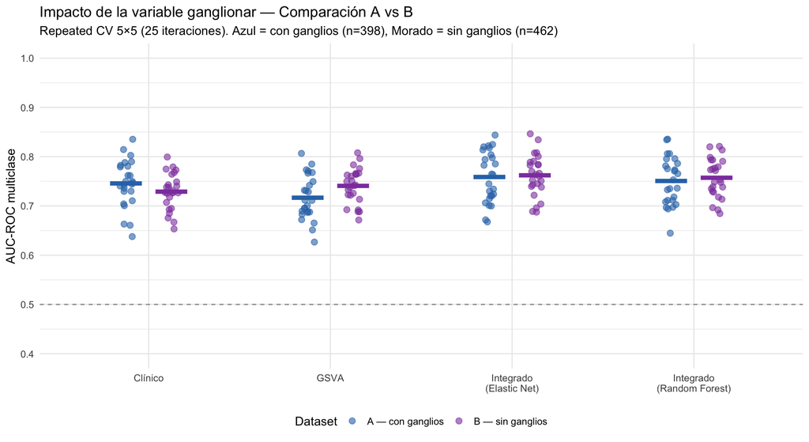

## 8.4 7.4 Variabilidad entre folds

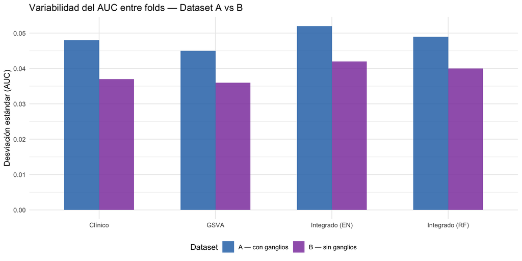

**Figura 2.** Desviación estándar del AUC entre las 25 iteraciones por modelo y dataset. Menor DE indica estimados más estables. Se espera que el Dataset B, con más muestras, produzca estimados más estables especialmente en la clase Baja.

# 9 8. Interpretación y decisión

El análisis de sensibilidad muestra que eliminar la variable ganglionar produce un cambio de -0.017 puntos en el modelo clínico (en contra del Dataset B) y de 0.003 puntos en el modelo integrado Elastic Net. Ambos modelos son **equivalentes** en términos de AUC.

**Tabla 5.** Criterios cuantitativos y cualitativos para la decisión sobre la variable ganglionar.

| Criterio de decisión | Dataset A (con ganglios) | Dataset B (sin ganglios) |
| --- | --- | --- |
| AUC modelo clínico (Δ B−A) | 0.746 | 0.729 |
| AUC modelo integrado EN (Δ B−A) | 0.759 | 0.762 |
| AUC modelo integrado RF (Δ B−A) | 0.751 | 0.757 |
| Estabilidad — DE modelo clínico (A vs B) | 0.048 | 0.037 |
| Tamaño clase Baja (A vs B) | 21 | 41 |
| Completitud variable ganglionar en TCGA-PRAD | 85.3% cobertura | No aplicable |
| Relevancia clínica del estado ganglionar | Alta (sistema TNM) | No incluido |

- **Mantener la variable ganglionar (Dataset A)** es preferible si el objetivo es construir un modelo clínicamente completo y comparable con la literatura, asumiendo que la pérdida de 64 muestras es aceptable dado que la clase Intermedia y Alta siguen bien representadas.
- **Eliminarla (Dataset B)** es preferible si se prioriza el tamaño muestral y la estabilidad del estimado para la clase Baja, a costa de un modelo clínico menos informativo.

En cualquier caso, esta limitación se discutirá explícitamente en la memoria como una restricción inherente a la cobertura de la variable ganglionar en la cohorte TCGA-PRAD (85.3% de disponibilidad).

# 10 9. Guardar outputs

```r
dir.create("results/tables", recursive = TRUE, showWarnings = FALSE)

# Tabla comparativa completa
write_csv(comparacion, "results/tables/sensibilidad_ganglionar.csv")

# Dataset B por si se decide usarlo
saveRDS(dataset_B, "data/processed/dataset_B_sin_ganglios.rds")
```

# 11 10. Resumen ejecutivo

**Tabla 6.** Resumen del análisis de sensibilidad.

| Parámetro | Valor |
| --- | --- |
| Dataset A — N muestras | 397 |
| Dataset A — AUC clínico | 0.746 ± 0.048 |
| Dataset A — AUC integrado (EN) | 0.759 ± 0.052 |
| Dataset A — AUC integrado (RF) | 0.751 ± 0.049 |
| Dataset B — N muestras | 461 |
| Dataset B — AUC clínico | 0.729 ± 0.037 |
| Dataset B — AUC integrado (EN) | 0.762 ± 0.042 |
| Dataset B — AUC integrado (RF) | 0.757 ± 0.04 |
| Δ AUC clínico (B − A) | -0.017 |
| Δ AUC integrado EN (B − A) | 0.003 |
| Δ AUC integrado RF (B − A) | 0.007 |
| Conclusión | Ambas configuraciones equivalentes — decisión metodológica |

# 12 Referencias

Friedman, J., Hastie, T. y Tibshirani, R. (2010) ‘Regularization paths for generalized linear models via coordinate descent’, *Journal of Statistical Software*, 33(1), pp. 1–22. doi: 10.18637/jss.v033.i01.